# Species metadata description

# Biodiversity mapping

The following pdf gives a description of the data used in the pipeline run that corresponds to the folder this document resides in. It should be used as a guide for anyone who wants to know more about the data used in the corresponding outputs (maps and datasets) and/or would like to replicate the data.

We begin with basic information about the pipeline run.

[output not shown]

In addition to the above, data was downloaded with a maximum uncertainty regarding coordinates of 100 metres.

| taxa | species | redListedSpecies |
| --- | --- | --- |
| fungi | 2270 | 0 |
| lichens | 748 | 1 |
| vascularPlants | 1559 | 35 |

| dsName | dataType | observations | redListedObservations |
| --- | --- | --- | --- |
| Vascular Plants, Observations, Oslo (O) | PA | 1076673 | 124085 |
| Fungi field notes, Oslo (O) | PA | 38194 | 0 |
| Norwegian Species Observation Service | PO | 36282 | 367 |
| Lichen field notes, Oslo (O) | PA | 7227 | 9 |
| iNaturalist Research-grade Observations | PO | 3656 | 16 |
| Vascular plant herbarium TRH, NTNU University Museum | PO | 3514 | 10 |
| Overvåking av semi-naturlig eng (ASO) | PA | 2664 | 20 |
| Lichen herbarium TRH, NTNU University Museum | PO | 964 | 26 |
| Mycology herbarium TRH, NTNU University Museum | PO | 797 | 0 |
| Pl@ntNet automatically identified occurrences | PO | 569 | 1 |

The following gives species richness for observations across the surveyed region by taxa.

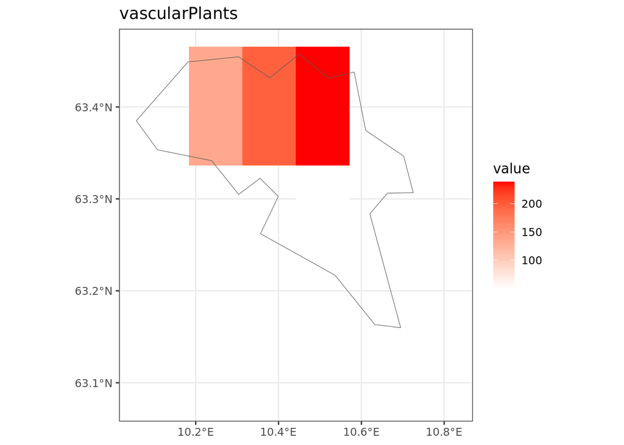

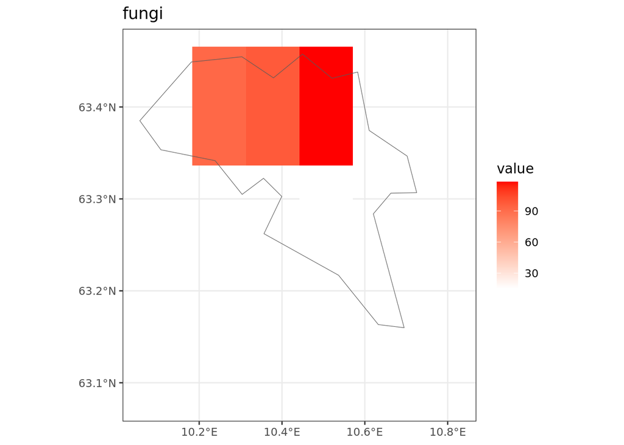

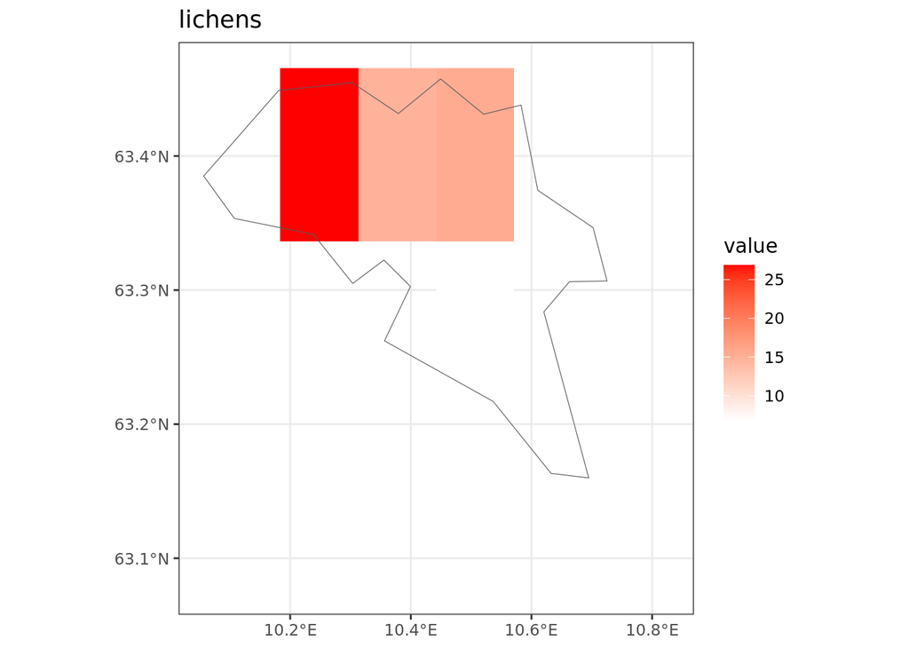

The following gives spatial density for observations across the surveyed region by taxa.

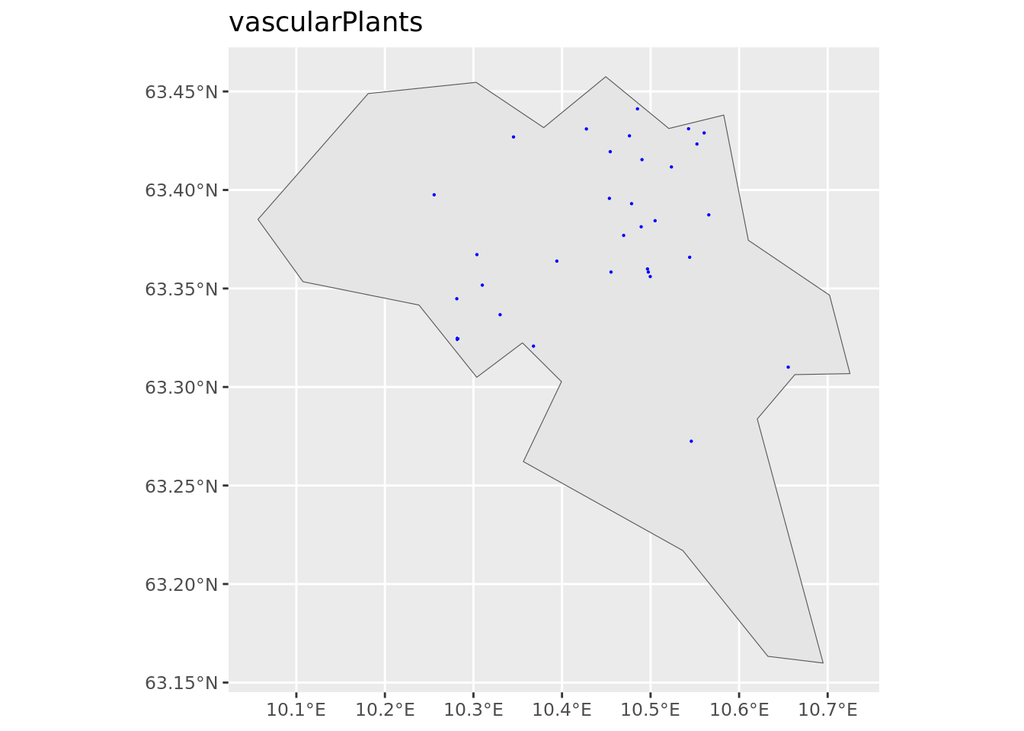

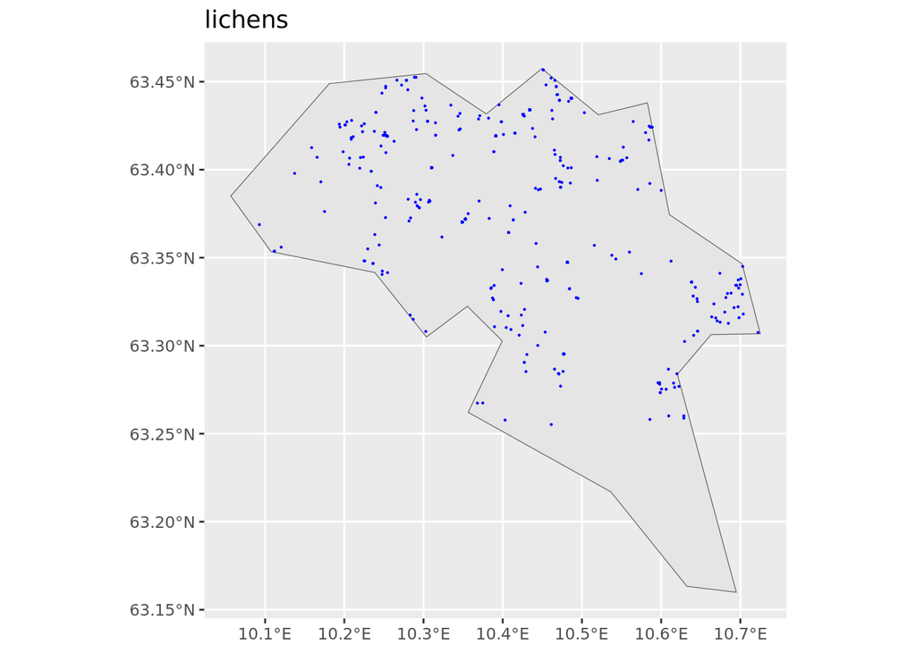

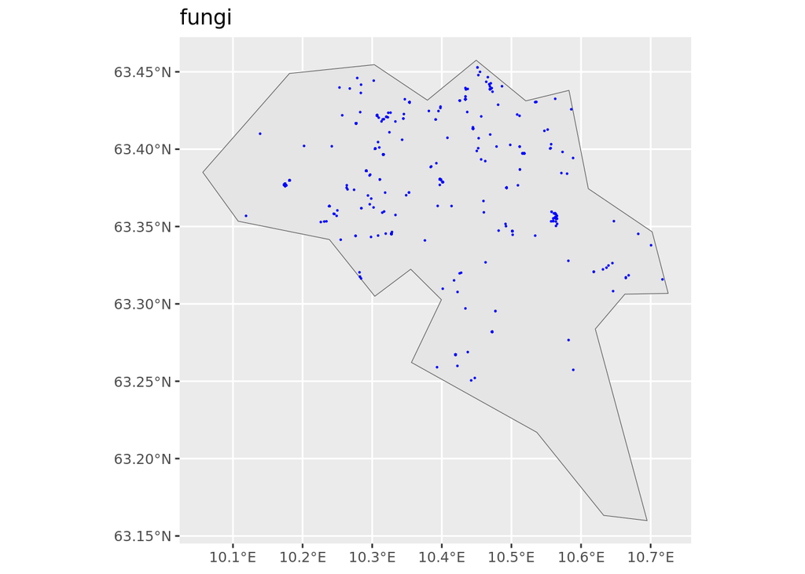

## Appendices

### Appendix 1

The tables below give further information on the observations used for our pipeline run.

Total numbers of observations used in pipeline run for each dataset by taxa.

| taxa | dsName | Observations |
| --- | --- | --- |
| fungi | Fungi field notes, Oslo (O) | 38116 |
| fungi | Norwegian Species Observation Service | 8744 |
| fungi | Lichen field notes, Oslo (O) | 1053 |
| fungi | Mycology herbarium TRH, NTNU University Museum | 797 |
| fungi | Lichen herbarium TRH, NTNU University Museum | 356 |
| fungi | iNaturalist Research-grade Observations | 126 |
| fungi | Fungarium, Oslo (O) UiO | 103 |
| fungi | Lichen herbarium, Oslo (O) UiO | 27 |
| fungi | Lichen herbarium, UiB | 12 |
| fungi | Norwegian specimens stored in Herb. Klepsland (pre 2022) | 7 |
| fungi | Observation.org, Nature data from around the World | 3 |
| lichens | Lichen field notes, Oslo (O) | 6174 |
| lichens | Norwegian Species Observation Service | 1508 |
| lichens | Lichen herbarium TRH, NTNU University Museum | 608 |
| lichens | iNaturalist Research-grade Observations | 278 |
| lichens | Lichen herbarium, Oslo (O) UiO | 93 |
| lichens | Fungi field notes, Oslo (O) | 78 |
| lichens | Lichen herbarium, UiB | 9 |
| lichens | Norwegian specimens stored in Herb. Klepsland (pre 2022) | 4 |
| lichens | Observation.org, Nature data from around the World | 2 |
| vascularPlants | Vascular Plants, Observations, Oslo (O) | 1076673 |
| vascularPlants | Norwegian Species Observation Service | 26030 |
| vascularPlants | Vascular plant herbarium TRH, NTNU University Museum | 3514 |
| vascularPlants | iNaturalist Research-grade Observations | 3252 |
| vascularPlants | Overvåking av semi-naturlig eng (ASO) | 2664 |
| vascularPlants | Pl@ntNet automatically identified occurrences | 569 |
| vascularPlants | Occurrence data from various smaller projects in Norway | 131 |
| vascularPlants | Vascular Plant Herbarium, Oslo (O) UiO | 99 |
| vascularPlants | Pl@ntNet observations | 98 |
| vascularPlants | Observation.org, Nature data from around the World | 91 |
| vascularPlants | ANOData | 32 |
| vascularPlants | Vascular plant herbarium (KMN) UiA | 10 |
| vascularPlants | Vascular plant herbarium, The Arctic University Museum of Norway (TROM) | 1 |

Total numbers of observations used in pipeline run for each data type by taxa.

| taxa | dataType | Observations |
| --- | --- | --- |
| fungi | PA | 39169 |
| fungi | PO | 10175 |
| lichens | PA | 6252 |
| lichens | PO | 2502 |
| vascularPlants | PA | 1079369 |
| vascularPlants | PO | 33795 |